# Trabajos Prácticos de Simulación [75.26]

- Albarracin, Dario Javier - 97568
- Bergman, Guido Ernesto - 104030
- del Mazo, Federico - 100029
- Rodriguez, Florencia - 100033
- Salgueiro Da Costa Riberio, Joao Luís

# Trabajo Práctico 1

# LXM

> LXM: Better Splittable Pseudorandom Number Generators (and Almost as Fast)
> - Paper: https://dl.acm.org/doi/abs/10.1145/3485525
> - Video: https://youtu.be/OXurCqln_qc

En el 2021 Guy Steele y Sebastiano Vigna presentaron un generador de números pseudo aleatorios (PRNG) que se construye a partir de otro PRNG en donde colaboró Guy Steele llamado SplitMix.

La principal propiedad de ambos PRNGs es que estos generadores son partibles (*splittable*), es decir, se pueden dividir en dos nuevos generadores estadísticamente independientes, lo cual es de gran utilidad en ambientes concurrentes.

LXM se basa en combinar tres ideas: un generador lineal congruente (la L), un generador basado en XORs (la X) y el resultado de la combinación de esos dos generadores utilizarlo como input en una función mezcladora (la M).

En este trabajo nos centraremos específicamente en la parte práctica del algoritmo y lo re-implementaremos en nuestro propio código, evitando hablar tanto de la concurrencia como de la propiedad partible del algoritmo (lo cual consiste de la mayoría del paper de Guy Steele y Sebastiano Vigna).

Las ideas principales de este trabajo surgen de la sección 2 del paper (`THE LXM GENERATION ALGORITHM`)

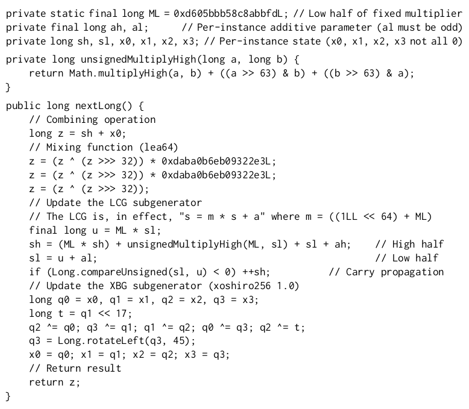

```python
def LXM(s, m=2891336453, a=1310709051, x0=11565345, x1=5242836, k=64):

    # https://gist.github.com/trietptm/5cd60ed6add5adad6a34098ce255949a
    rotl = lambda val, r_bits, max_bits: \
        (val << r_bits%max_bits) & (2**max_bits-1) | \
        ((val & (2**max_bits-1)) >> (max_bits-(r_bits%max_bits)))

    while True:
        # Combining operation
        z = s + x0
        # Mixing function (lea64)
        z = (z ^ (z >> 32)) * 0xdaba0b6eb09322e3
        z = (z ^ (z >> 32)) * 0xdaba0b6eb09322e3
        z = (z ^ (z >> 32))
        z &= (2**k) - 1
        # Update the LCG subgenerator
        s = (m * s + a)
        # Update the XBG subgenerator (xoroshiro128v1_0)
        q0 = x0; q1 = x1
        q1 ^= q0
        q0 = rotl(q0, 24, k)
        q0 = q0 ^ q1 ^ (q1 << 16)
        q1 = rotl(q1, 37, k)
        x0 = q0; x1 = q1
        # Return result (modified to be in interval 0-1)
        yield z/2**k
```

```python
n = 5
print(f"{n} números generados al azar, en el intervalo 0-1:")

g = LXM(42)
for r, i in zip(g,range(n)):
    print(f"* {r}")
```

```
5 números generados al azar, en el intervalo 0-1:
* 0.793781427453092
* 0.2155520740899848
* 0.7433470653358116
* 0.28660629734277526
* 0.515362051632894
```

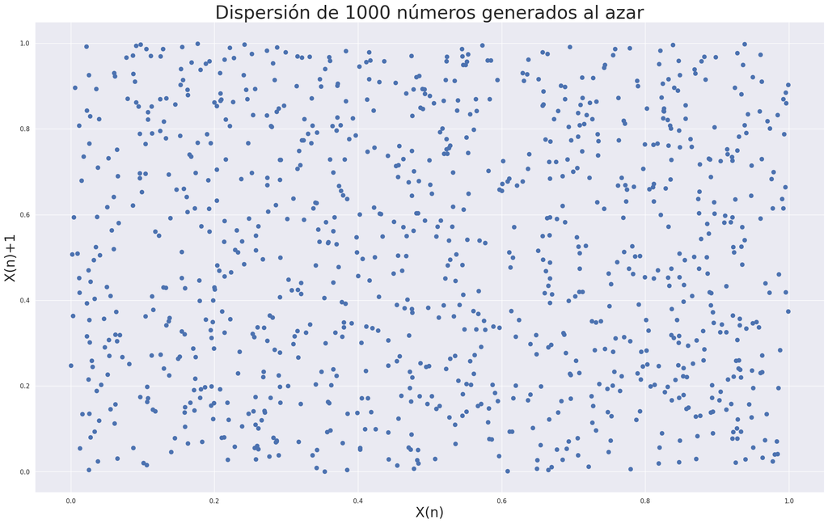

```python
scatterplot.show()
```

En el gráfico de dispersión se pretende ver si la generación de los números sigue algún patrón. En el gráfico realizado no se observa ninguno, ya que no se ven formas claras, como por ejemplo una línea recta, ni zonas con una densidad marcadamente superior a la del resto. Lo que se observa es una "nube de puntos", que es lo que debería verse en una distribución uniforme.

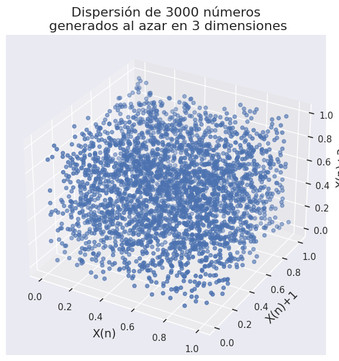

```python
scatter3D.show()
```

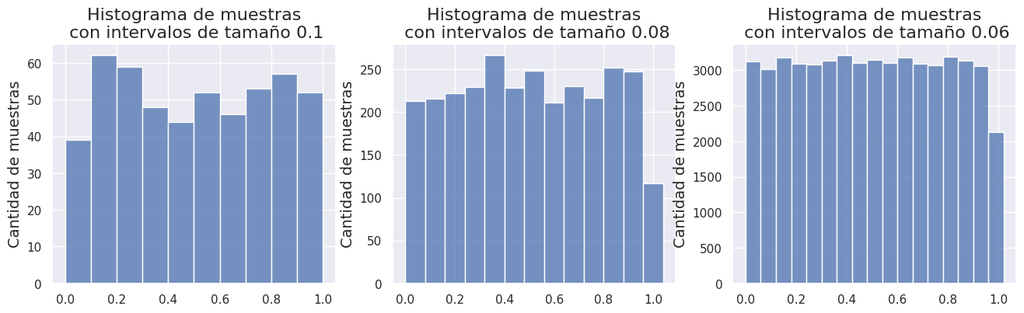

```python
histogramas.show()
```

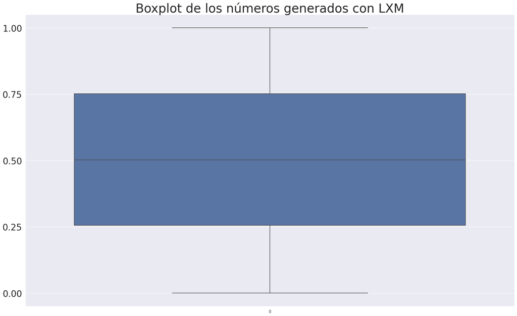

```python
boxplot.show()
```

Un boxplot muestra los cuartiles de los números generados, el soporte de la distribución y los outliers. Para el caso actual, se puede utilizar para comparar esos datos con los de una distribución uniforme. Así, se puede ver que:

- Los cuartiles son los esperados. Esto se debe a que el del 25% coincide con 0.25, el de 50% con 0.5 y el de 75% con 0.75
- El soporte es entre 0 y 1
- No se observan outliers

```python
qqplot.show()
```

[output not shown]

## Test Estadísticos

- Test de Chi2
- Test de Gap
- Test de Independencia

### Test de Chi2

Con este método comparamos dos distribuciones de probabilidad. Por una parte, la observada, que es la que obtenemos utilizando nuestro generador LXM. Por otra parte, la distribución esperada, que es la distribución que queremos corroborar que la observada sigue.

```python
from scipy.stats import chi2
import numpy as np
import math

class Chi2:
    def __init__(self, numero_de_muestras=1000, g = None):
        self._generador = g or LXM(42)
        self._numero_de_muestras = numero_de_muestras

    def realizar_prueba(self):
        frecuencias_observadas = self.frecuencias_observadas()

        f_esperada = 1/10 * sum(frecuencias_observadas)
        d2 = sum([(f_observada - f_esperada)**2 for f_observada in frecuencias_observadas]) / f_esperada

        limite_superior = chi2.ppf(0.95, df=5)
        print(f'Frecuencias: {frecuencias_observadas}')
        print('Estadístico: {:.2f}'.format(d2))
        print(f'Límite superior: {round(limite_superior, 2)}')
        self.validar_hipotesis(d2, limite_superior)

    def calcular_d2(self):
        numerador = (f_observada - f_esperada) ** 2
        denominador =  f_esperada
        d_al_cuadrado = numerador / denominados # acá es sumatoria

    def validar_hipotesis(self, d2, limite_superior):
        if d2 <= limite_superior:
            print("El test acepta la hipotesis nula")
        else:
            print("El test rechaza la hipótesis nula")

    def frecuencias_observadas(self):
        # Estas son las que tengo que obtener
        numeros_generados = []
        for i in range(self._numero_de_muestras):
            numeros_generados.append(next(self._generador))
        frecuencias = [0] * 10
        for numero in numeros_generados:
            pos = math.floor(numero*10)
            if pos < 10:
                frecuencias[pos] += 1
        return frecuencias
```

```python
def pseudo_chi2():
    # Obtengo freuencias observadas de 0 a 9 (enteros)
    # La frecuencia esperada es 1/10  por la cantidad de números aleatorios que genero
    # Con estos valores ahora entonces calculo d2
    # d2 = sum (frecuencia_observada - frecuencia_esperada) ** 2  / frecuencia_esperada
    # Finalmente para chi2.ppf(0.95, df=5) vemos si d2 es mayor o menos al limite superior
    return
```

```python
# Corremos nuestro experimento
Chi2(numero_de_muestras=10000).realizar_prueba()
```

```
Frecuencias: [949, 998, 1019, 1007, 1008, 998, 1029, 968, 1001, 1023]
Estadístico: 5.48
Límite superior: 11.07
El test acepta la hipotesis nula
```

### Test de Gap

Este test consiste en contar la cantidad de números aleatorios generados que no pertenecen a un intervalo dado, tal que consigamos 'gaps'. Para este test decidimos generar 1000 gaps y utilizar el intervalo [0.2, 0,5].

Finalmente aplicamos chi2 para validar (o rechazar) la hipótesis.

```python
import matplotlib.pyplot as plt

class Gap:
    def __init__(self, cota_inferior, cota_superior, g = None):
        self._generador = g or LXM(42)
        self._cota_inferior = cota_inferior
        self._cota_superior = cota_superior
        self._p_0 = cota_superior - cota_inferior
        self._cantidad_de_gaps = 1000

    def realizar_prueba(self):
        # Espero a la primera vez que tengo valor dentro de la cota
        gaps = self.generar_gaps()
        self.plotear_gaps(gaps)
        frecuencias_observadas = self.generar_frecuencias(gaps)
        d2 = 0

        # Aplicamos chi2
        for i, frecuencia_observada in enumerate(frecuencias_observadas):
            f_esperada = self.frecuencia_esperada(i)
            numerador = (frecuencia_observada - f_esperada) ** 2
            denominador = f_esperada
            d2 += numerador / denominador

        # Validamos hipótesis
        k = len(frecuencias_observadas)
        limite_superior = chi2.ppf(0.95, df=k-1)
        print('Estadístico: {:.2f}'.format(d2))
        print(f'Límite superior: {round(limite_superior, 2)}')
        self.validar_hipotesis(d2, limite_superior)

    def validar_hipotesis(self, d2, limite_superior):
        if d2 <= limite_superior:
            print("El test acepta la hipotesis nula")
        else:
            print("El test rechaza la hipótesis nula")

    def generar_gaps(self):
        gaps = []
        # Generamos 1000 gaps
        while(len(gaps) < self._cantidad_de_gaps):
            while (True):
                n = next(self._generador)
                if n < self._cota_superior and n > self._cota_inferior:
                    break
            gap = 0
            while(True):
                n = next(self._generador)
                if n < self._cota_superior and n > self._cota_inferior:
                    gaps.append(gap)
                    break
                else:
                    gap +=1
        return gaps

    def plotear_gaps(self, gaps):
        plt.hist(gaps, color='b', bins="sturges", alpha=0.8, density=True, rwidth=0.8, align='left')
        plt.show()

    def generar_frecuencias(self, gaps):
        frecuencias = [0] * (max(gaps) + 1)
        for gap in gaps:
            frecuencias[gap] += 1
        return frecuencias

    def frecuencia_esperada(self, n):
        return (((1 - self._p_0)**n) * self._p_0) * self._cantidad_de_gaps
```

```python
def pseudo_gap():
    # Obtengo gaps entre un rango de valores
    # (dentro de [0,1]  ya que son los valores que genera el LXM programado
    # Con estos valores ahora entonces calculo d2
    # d2 = sum (frecuencia_observada - frecuencia_esperada) ** 2  / frecuencia_esperada
    # La  frecuencia esperada podrá ser distinta para cada valor, ya que
    # la misma sigue una distribución geométrica
    # Finalmente para chi2.ppf(0.95, df=cantidad_de_gaps) vemos si d2 es mayor o menos al limite superior
    return
```

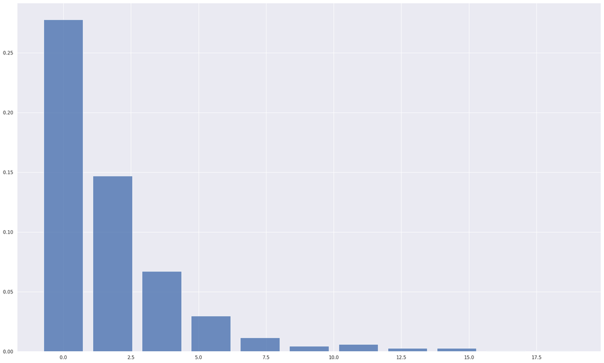

```
Estadístico: 21.92
Límite superior: 31.41
El test acepta la hipotesis nula
```

```python
# Corremos nuestro experimento
Gap(cota_inferior=0.2, cota_superior=0.5).realizar_prueba()
```

### Test de Independencia

Con este métod vamos a validar que las variables sean independientes.

```python
from scipy.stats import chi2_contingency


class TestIndependencia:
    def __init__(self, g = None):
        self._generador = g or LXM(42)
        self._cantidad_de_vectores = 500

    def realizar_prueba(self):
        nros_x = []
        nros_y = []

        for i in range(self._cantidad_de_vectores):
            nros_x.append(next(self._generador))
            nros_y.append(next(self._generador))

        self.plot_vectores(nros_x, nros_y)

        d2, p, dof, ex = chi2_contingency([nros_x, nros_y], correction=True)

        # Validamos hipótesis
        limite_superior = chi2.ppf(0.95, df=dof)
        print('Estadístico: {:.2f}'.format(d2))
        print(f'Límite superior: {round(limite_superior, 2)}')
        self.validar_hipotesis(d2, limite_superior)

    def validar_hipotesis(self, d2, limite_superior):
        if d2 <= limite_superior:
            print("El test acepta la hipotesis nula")
        else:
            print("El test rechaza la hipótesis nula")

    def plot_vectores(self, nros_x, nros_y):
        plt.title(f"Dispersión de {self._cantidad_de_vectores} números generados al azar")
        plt.ylabel("X(n)-1")
        plt.xlabel("X(n)")
        plt.scatter(nros_x,nros_y,50)
        plt.show()
```

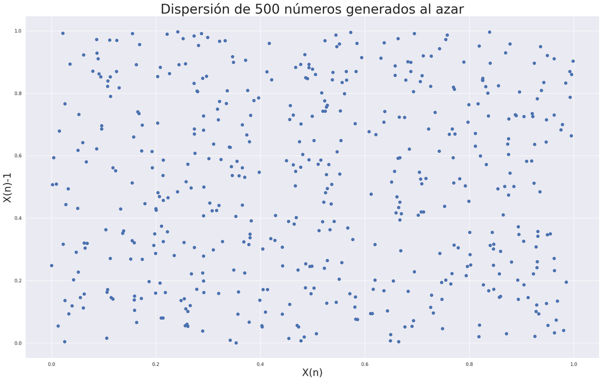

```
Estadístico: 87.60
Límite superior: 552.07
El test acepta la hipotesis nula
```

```python
# Corremos nuestro experimento
TestIndependencia().realizar_prueba()
```

## Ejercicio 3

Utilizando el generador implementado en el ejercicio 1:

- Implementar un método para generar variables aleatorias con distribución normal con media 10 y desvío 2.
- Graficar la distribución que siguen los números pseudoaleatorios generados.
- Realizar, al menos 2 tests, de los explicados en la materia, para verificar si los números generados siguen la distribución pedida (evalué los resultados para distintos tamaños de muestra).

```python
gen = LXM(42)

def generar_exponencial(lambda_):
    u_1 = next(gen)
    return -np.log(u_1)/lambda_

def cociente(t):
    return e**((-(t-1)**2)/2)

def transformar_gaussiana(x, mean, std):
    return x*std + mean

def generar_normal_0_1():
    no_aceptada = True
    while(no_aceptada):
        exp_1 = generar_exponencial(1)
        prob = cociente(exp_1)
        if(next(gen) < prob):
            no_aceptada = False
            z = exp_1
            if(next(gen) < 0.5):
                z = -z
    return z
```

```python
m1, m2, m3 = [], [], []     #muestras
for i in range(100):
    z1 = generar_normal_0_1()
    z2 = transformar_gaussiana(z1, 10, 2)
    m1.append(z2)

for i in range(1000):
    z1 = generar_normal_0_1()
    z2 = transformar_gaussiana(z1, 10, 2)
    m2.append(z2)

for i in range(10000):
    z1 = generar_normal_0_1()
    z2 = transformar_gaussiana(z1, 10, 2)
    m3.append(z2)
```

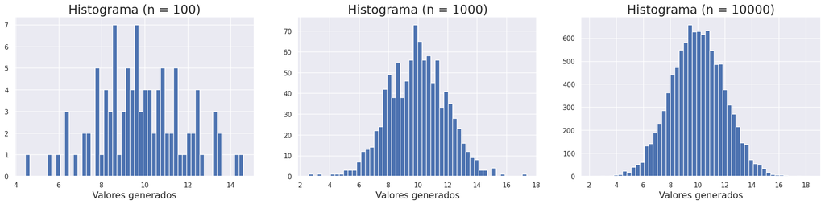

```python
fig, (ax1, ax2, ax3) = plt.subplots(1, 3, figsize=(20, 5))
fig.tight_layout(pad=3)
ax1.hist(m1, 50)
ax1.set_xlabel('Valores generados', fontsize=15)
ax1.set_title("Histograma (n = 100)", fontsize=20)
ax2.hist(m2, 50)
ax2.set_xlabel('Valores generados', fontsize=15)
ax2.set_title("Histograma (n = 1000)", fontsize=20)
ax3.hist(m3, 50)
ax3.set_xlabel('Valores generados', fontsize=15)
ax3.set_title("Histograma (n = 10000)", fontsize=20)

plt.show();
```

### Test de Kolmogorov-Smirnov

El test de Kolmogorov-Smirnov se utiliza para decidir si una muestra proviene de una población con una distribución específica.

Se tiene una distribución de probabilidad acumulada, la cual se propone como distribución teórica de la muestra, y otra distribución de probabilidad empirica, generada a partir de la muestra.

En este caso tenemos las hipótesis:

$H_0$: La muestra pertenece a una poblacion con la distribución teórica propuesta  
$H_1$: La muestra no pertenece a una poblacion con la distribución teórica propuesta.  
El test provee como resultados un estadístico y un p-valor. Cuando el p-valor obtenido es superior a cierto umbral --usualmente 0.05--, decimos que no podemos rechazar la hipótesis de que los datos provienen de una población con la distribución teórica propuesta.

```python
m1_ks, m2_ks, m3_ks = [], [], []     #muestras
for i in range(100):
    z1 = generar_normal_0_1()
    z2 = transformar_gaussiana(z1, 10, 2)
    m1_ks.append(z2)

for i in range(1000):
    z1 = generar_normal_0_1()
    z2 = transformar_gaussiana(z1, 10, 2)
    m2_ks.append(z2)

for i in range(5000):
    z1 = generar_normal_0_1()
    z2 = transformar_gaussiana(z1, 10, 2)
    m3_ks.append(z2)
```

```python
state = np.random.default_rng()
dist_teorica_1 = sp.stats.norm(loc=10, scale=2).rvs(size=100, random_state=state)
dist_teorica_2 = sp.stats.norm(loc=10, scale=2).rvs(size=1000, random_state=state)
dist_teorica_3 = sp.stats.norm(loc=10, scale=2).rvs(size=5000, random_state=state)
```

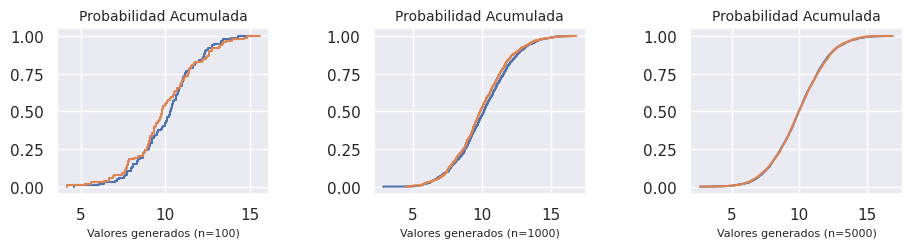

```python
figsts, (ax1sts, ax2sts, ax3sts) = plt.subplots(1, 3, figsize=(10, 3))
figsts.tight_layout(pad=3)

yval1 = np.linspace(0.0, 1.0,num=100)
ax1sts.step(x=np.sort(m1_ks), y=yval1)
ax1sts.step(x=np.sort(dist_teorica_1), y=yval1)
ax1sts.set_xlabel('Valores generados (n=100)', fontsize=8)
ax1sts.set_title("Probabilidad Acumulada", fontsize=10)

yval2 = np.linspace(0.0, 1.0,num=1000)
ax2sts.step(x=np.sort(m2_ks), y=yval2)
ax2sts.step(x=np.sort(dist_teorica_2), y=yval2)
ax2sts.set_xlabel('Valores generados (n=1000)', fontsize=8)
ax2sts.set_title("Probabilidad Acumulada", fontsize=10)

yval3 = np.linspace(0.0, 1.0,num=5000)
ax3sts.step(x=np.sort(m3_ks), y=yval3)
ax3sts.step(x=np.sort(dist_teorica_3), y=yval3)
ax3sts.set_xlabel('Valores generados (n=5000)', fontsize=8)
ax3sts.set_title("Probabilidad Acumulada", fontsize=10)
```

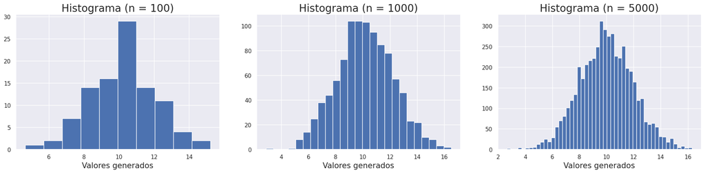

```python
figks, (ax1ks, ax2ks, ax3ks) = plt.subplots(1, 3, figsize=(20, 5))
figks.tight_layout(pad=3)
ax1ks.hist(m1_ks, 10)
ax1ks.set_xlabel('Valores generados', fontsize=15)
ax1ks.set_title("Histograma (n = 100)", fontsize=20)
ax2ks.hist(m2_ks, 25)
ax2ks.set_xlabel('Valores generados', fontsize=15)
ax2ks.set_title("Histograma (n = 1000)", fontsize=20)
ax3ks.hist(m3_ks, 50)
ax3ks.set_xlabel('Valores generados', fontsize=15)
ax3ks.set_title("Histograma (n = 5000)", fontsize=20)

plt.show();
```

```python
from scipy import stats
ks1 = stats.kstest(m1_ks, dist_teorica_1, alternative='two-sided')
ks2 = stats.kstest(m2_ks, dist_teorica_2, alternative='two-sided')
ks3 = stats.kstest(m3_ks, dist_teorica_3, alternative='two-sided')

display ("Valor del estadístico del test Kolmogorov-Smirnov con n = 100: " + str(ks1.statistic))
display ("P-valor del test Kolmogorov-Smirnov con n = 100: " + str(ks1.pvalue))
display ("Valor del estadístico del test Kolmogorov-Smirnov con n = 1000: " + str(ks2.statistic))
display ("P-valor del test Kolmogorov-Smirnov con n = 1000: " + str(ks2.pvalue))
display ("Valor del estadístico del test Kolmogorov-Smirnov con n = 5000: " + str(ks3.statistic))
display ("P-valor del test Kolmogorov-Smirnov con n = 5000: " + str(ks3.pvalue))
```

```
'Valor del estadístico del test Kolmogorov-Smirnov con n = 100: 0.14'
```

```
'P-valor del test Kolmogorov-Smirnov con n = 100: 0.2819416298082479'
```

```
'Valor del estadístico del test Kolmogorov-Smirnov con n = 1000: 0.058'
```

```
'P-valor del test Kolmogorov-Smirnov con n = 1000: 0.06917625399020766'
```

```
'Valor del estadístico del test Kolmogorov-Smirnov con n = 5000: 0.0126'
```

```
'P-valor del test Kolmogorov-Smirnov con n = 5000: 0.8223009941322108'
```

Dado que en todos los casos el p-valor es superior a 0.05, no rechazamos la hipótesis de que los datos provienen de una distribución normal.

### Test de Shapiro-Wilk

El test de Shapiro-Wilk está diseñado para decidir si una muestra aleatoria proviene de una distribución normal. En este caso se cuenta con las siguientes hipótesis:

$H_0$: Los datos provienen de una distribución normal

$H_1$: Los datos no provienen de una distribución normal

El test provee como resultados un estadístico y un p-valor. Cuando el p-valor obtenido es superior a cierto umbral --usualmente 0.05--, decimos que no podemos rechazar la hipótesis de que los datos provienen de una distribución normal.

La implementación utilizada (scipy) indica que para muestras de más de 5000 números, se pierde precisión en los valores del test. Por lo que se realizará el test para muestras de tamaños N = 100, 1000 y 5000. (Ver: https://docs.scipy.org/doc/scipy/reference/generated/scipy.stats.shapiro.html?highlight=shapiro)

```python
m1_sw, m2_sw, m3_sw = [], [], []     #muestras
for i in range(100):
  z1 = generar_normal_0_1()
  z2 = transformar_gaussiana(z1, 10, 2)
  m1_sw.append(z2)

for i in range(1000):
  z1 = generar_normal_0_1()
  z2 = transformar_gaussiana(z1, 10, 2)
  m2_sw.append(z2)

for i in range(5000):
  z1 = generar_normal_0_1()
  z2 = transformar_gaussiana(z1, 10, 2)
  m3_sw.append(z2)
```

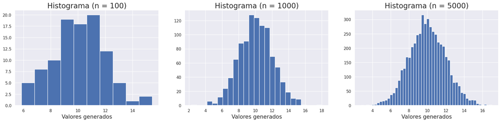

```python
figsw, (ax1sw, ax2sw, ax3sw) = plt.subplots(1, 3, figsize=(20, 5))
figsw.tight_layout(pad=3)
ax1sw.hist(m1_sw, 10)
ax1sw.set_xlabel('Valores generados', fontsize=15)
ax1sw.set_title("Histograma (n = 100)", fontsize=20)
ax2sw.hist(m2_sw, 25)
ax2sw.set_xlabel('Valores generados', fontsize=15)
ax2sw.set_title("Histograma (n = 1000)", fontsize=20)
ax3sw.hist(m3_sw, 50)
ax3sw.set_xlabel('Valores generados', fontsize=15)
ax3sw.set_title("Histograma (n = 5000)", fontsize=20)

plt.show();
```

```python
from scipy import stats
shapiro1 = stats.shapiro(m1_sw)
shapiro2 = stats.shapiro(m2_sw)
shapiro3 = stats.shapiro(m3_sw)

display ("Valor del estadístico del test Shapiro-Wilk con n = 100: " + str(shapiro1.statistic))
display ("P-valor del test Shapiro-Wilk con n = 100: " + str(shapiro1.pvalue))
display ("Valor del estadístico del test Shapiro-Wilk con n = 1000: " + str(shapiro2.statistic))
display ("P-valor del test Shapiro-Wilk con n = 1000: " + str(shapiro2.pvalue))
display ("Valor del estadístico del test Shapiro-Wilk con n = 5000: " + str(shapiro3.statistic))
display ("P-valor del test Shapiro-Wilk con n = 5000: " + str(shapiro3.pvalue))
```

```
'Valor del estadístico del test Shapiro-Wilk con n = 100: 0.9904636740684509'
```

```
'P-valor del test Shapiro-Wilk con n = 100: 0.7020654678344727'
```

```
'Valor del estadístico del test Shapiro-Wilk con n = 1000: 0.9989786744117737'
```

```
'P-valor del test Shapiro-Wilk con n = 1000: 0.8619867563247681'
```

```
'Valor del estadístico del test Shapiro-Wilk con n = 5000: 0.9995430111885071'
```

```
'P-valor del test Shapiro-Wilk con n = 5000: 0.28750666975975037'
```

Dado que el p-valor es superior a 0.05, no rechazamos la hipótesis de que los datos provienen de una distribución normal.

# Proceso de Poisson

```python
arribos_real = []
with open("TP1/tiempos_entre_arribos.txt") as f:
    for l in f.readlines(): arribos_real.append(float(l.strip()))

tasa = len(arribos_real)/sum(arribos_real)
print(f"Tengo {len(arribos_real)} arribos en {sum(arribos_real)} horas")
print(f"Mi tasa de arribos empírica es de {tasa} arribos por hora")
```

```
Tengo 10000 arribos en 1011.1994386169154 horas
Mi tasa de arribos empírica es de 9.889245996494681 arribos por hora
```

```python
# Para generar eventos de Poisson:
#  1. Generar muestras de una distribución exponencial Z,
#     con parametro Lambda: z1, z2, z3...
#  2. Definir tiempos de eventos conteo de Poisson:
#     t0 = 0, t1 = t0 + z1, t2 = t1 + z2....

def iter_exponencial(lmbda, generador, n):
    """Genera una secuencia que siga una distribución exponencial,
       dado un generador que sigue una distribución uniforme"""
    u = np.array([next(generador) for i in range(int(n))])
    x = -np.log(1-u)/lmbda
    return iter(x)

def generar_poisson(limite, lmbda, generador):
    expo = iter_exponencial(lmbda, generador, lmbda*limite*1.5)
    arribos = []
    t = 0
    while t <= limite:
        arribo = next(expo)
        arribos.append(arribo)
        t += arribo
    return arribos

limite = 24 * 31 # Un mes
arribos = generar_poisson(limite, tasa, LXM(42))

print(f"Simulé {len(arribos)} arribos en {sum(arribos)} horas")
print(f"Mi tasa de arribos simulada es de {len(arribos)/sum(arribos)} arribos por hora")
```

```
Simulé 7300 arribos en 744.064522714941 horas
Mi tasa de arribos simulada es de 9.810977109033201 arribos por hora
```

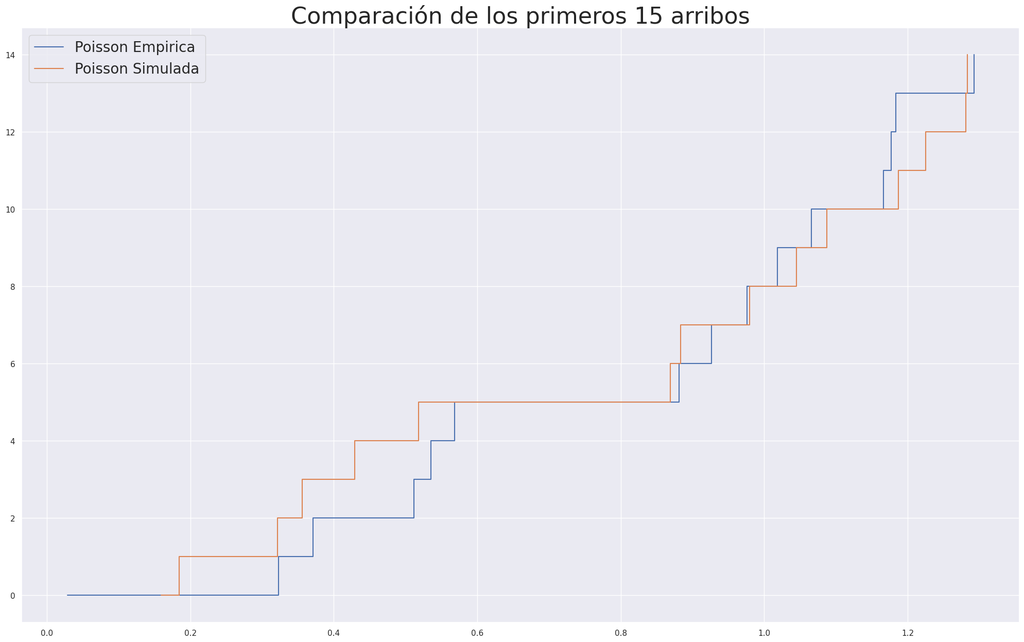

```python
def comparar_poissones(poissones_con_label, n = 15):
    for arribos, label in poissones_con_label:
        plt.step(np.cumsum(arribos[:n]),range(n),where= 'post',label=label)
    plt.legend()
    plt.title(f"Comparación de los primeros {n} arribos")
    plt.show()

comparar_poissones([(arribos_real, "Poisson Empirica"), (arribos, "Poisson Simulada")])
```

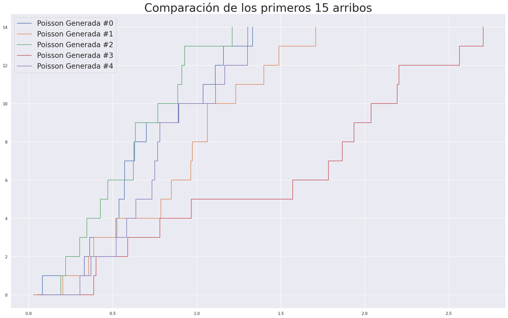

```python
limite = 96
poissones = []
for i in range(1000):
    poissones.append(generar_poisson(limite, tasa, LXM(i)))

comparar_poissones([(p, f"Poisson Generada #{i}") for i, p in enumerate(poissones[:5])])
```

```python
import math

# PMF de poisson, a mano, para comparar con los valores teóricos
pmf = lambda x, lmbda: ((lmbda ** x) * (math.e ** -lmbda)) / (math.factorial(x))

print("Probabilidad que el primer vehículo arribe antes de los 10 minutos.")
diez_min = 1/6


# La probabilidad de que haya al menos un arribo en 10 minutos equivale a
#   1 - la probabilidad de que no haya ningun arribo en 10 minutos
print(f"* Probabilidad Teórica => {1 - pmf(0, tasa*diez_min)}")

favorable = []
for p in poissones:
    favorable.append(p[0] <= diez_min)

print(f"* Probabilidad Simulada => {sum(favorable)/len(favorable)}")
```

```
Probabilidad que el primer vehículo arribe antes de los 10 minutos.
* Probabilidad Teórica => 0.8076055651533732
* Probabilidad Simulada => 0.818
```

```python
print("Probabilidad que el undécimo vehículo arribe después de los 60 minutos.")
sesenta_min = 1

# La probabilidad de que el vehiculo 11 llegué despues de 60 minutos equivale a
#   la sumatoria de que hayan llegado 0,1,2,...,10 vehiculos en 60 minutos
# Ojo con los off-by-one! `for i in range(11)` === de 0 a 10
print(f"* Probabilidad Teórica => {sum([pmf(i, tasa*sesenta_min) for i in range(11)])}")

favorable = []
for p in poissones:
    arribos_acumulados = np.cumsum(p)
    # El arribo en el indice [10] === El undecimo arribo
    favorable.append(arribos_acumulados[10] >= 1)

print(f"* Probabilidad Simulada => {sum(favorable)/len(favorable)}")
```

```
Probabilidad que el undécimo vehículo arribe después de los 60 minutos.
* Probabilidad Teórica => 0.596893339441658
* Probabilidad Simulada => 0.579
```

```python
# Como nuestra pmf a mano da overflow al calcular un número grande como lambda a la 750,
#   importamos directamente el modulo de scipy
from scipy.stats import poisson

print("Probabilidad que arriben al menos 750 vehículos antes de las 72 horas.")
setentidos_horas = 72

# La probabilidad de que arriben al menos 750 vehiculos en 72 horas equivale a
#   1 - la sumatoria de que lleguen 0,1,...,749 en 72 horas
print(f"* Probabilidad Teórica => {1 - sum([poisson.pmf(i, tasa*setentidos_horas) for i in range(750)])}")

favorable = []
for p in poissones:
    arribos_acumulados = np.cumsum(p)
    favorable.append(arribos_acumulados[749] <= 72)

print(f"* Probabilidad Simulada => {sum(favorable)/len(favorable)}")
```

```
Probabilidad que arriben al menos 750 vehículos antes de las 72 horas.
* Probabilidad Teórica => 0.08097848535892749
* Probabilidad Simulada => 0.084
```

## Ejercicio 5

A partir del generador de número al azar implementado en el ejercicio 1, y del dataset provisto, obtenido del sitio de datos abiertos del Gobierno de la Ciudad de Buenos Aires (data.buenosaires.gob.ar), el cual contiene información geográfica de barrios de la Ciudad de Buenos Aires, se pide:

- Proponer e implementar un método que permita generar coordenadas (latitud y longitud) distribuidas de forma uniforme en cada uno de los barrios.
- Graficar los puntos generados en el mapa

```python
class EJ5:

    def __init__(self, gdf, lxm):
        self.gdf = gdf.copy()
        self.lxm = lxm
        self.puntos_en_barrios = {}
        for barrio in self.gdf['BARRIO'].tolist():
            self.puntos_en_barrios[barrio] = [[],[]]

    def emitir_barrios(self):
        display(self.gdf['BARRIO'])

    #metodo auxiliar para trasladar un barrio al primer cuadrante
    def trasladar_barrio(self, datos_barrio):
        extremos_barrio = datos_barrio.geometry.bounds

        signo1 = 1
        signo2 = 1

        if(extremos_barrio.iloc[0]['minx'] < 0):
            signo1 = -1
        if(extremos_barrio.iloc[0]['miny'] < 0):
            signo2 = -1

        return datos_barrio.translate(extremos_barrio.iloc[0]['minx']*signo1, extremos_barrio.iloc[0]['miny']*signo2)

    #Generar n puntos en un barrio
    def generar_en_barrio(self, barrio, cantidad):
        x, y = [], []

        #obtengo la geometria del barrio, la traslado al primer cuadrante
        #y busco el maximo entre sus extremos para formar un cuadrado que los contenga
        datos_barrio = self.gdf[self.gdf['BARRIO']==barrio]
        g_barrio = datos_barrio['geometry']
        g_barrio_t = self.trasladar_barrio(datos_barrio)
        extremos_b = datos_barrio.bounds.to_numpy()
        extremos_t = g_barrio_t.bounds.to_numpy()
        maximo_t = np.amax(extremos_t)

        #genero puntos dentro del cuadrado que obtuve, y los acepto si están dentro del barrio
        x = []
        y = []
        while len(x) < cantidad:
            z1 = next(self.lxm) * maximo_t
            z2 = next(self.lxm) * maximo_t
            ps = shapely.geometry.Point(z1, z2)

            if g_barrio_t.contains(ps).any():
                x.append(z1 + datos_barrio.geometry.bounds.minx)
                y.append(z2 + datos_barrio.geometry.bounds.miny)

        self.puntos_en_barrios[barrio] = [x, y]


    #Generar n puntos en todos los barrios
    def generar_en_todos(self, n):
        for barrio in self.gdf['BARRIO'].tolist():
            self.generar_en_barrio(barrio, n)

    #Graficar un barrio y los puntos generados en el mismo
    def graficar_en_barrio(self, barrio):
        x = self.puntos_en_barrios[barrio][0]
        y = self.puntos_en_barrios[barrio][1]
        title_string = "Puntos generados en el barrio de {} (n = {})".format(barrio, len(x))

        fig, ax = plt.subplots(figsize=(10, 10))
        fig.tight_layout(pad=3)
        ax.set_title(title_string, fontsize=20)

        datos_barrio = self.gdf.loc[self.gdf['BARRIO']==barrio]
        datos_barrio.plot(ax=ax, color='white', edgecolor='black')
        ax.scatter(x, y, s=3, color="red")
        ax.grid()

        return fig, ax

    #Graficar el mapa completo y los puntos generados en un barrio
    def graficar_mapa_completo_barrio(self, nombre_barrio):
        x = self.puntos_en_barrios[nombre_barrio][0]
        y = self.puntos_en_barrios[nombre_barrio][1]
        title_string = "Puntos generados en el barrio de {} (n = {})".format(nombre_barrio, len(x))

        fig, ax = plt.subplots(figsize=(10, 10))
        fig.tight_layout(pad=3)
        ax.set_title(title_string, fontsize=20)
        self.gdf.plot(ax=ax, color='white', edgecolor='black')
        ax.scatter(x, y, s=3, color="red")
        ax.grid()

        return fig, ax

    #Graficar el mapa completo y los puntos generados en todos los barrios (si hay)
    def graficar_mapa_completo_todos(self):
        title_string = "Puntos generados en todos los barrios."
        fig, ax = plt.subplots(figsize=(10, 10))
        fig.tight_layout(pad=3)
        ax.set_title(title_string, fontsize=20)

        self.gdf.plot(ax=ax, color='white', edgecolor='black')

        for b in self.gdf['BARRIO'].tolist():
            x = self.puntos_en_barrios[b][0]
            y = self.puntos_en_barrios[b][1]
            ax.scatter(x, y, s=3, color="red")
        ax.grid()

        return fig, ax

    def help(self):
        display("generar_en_barrio('barrio', cantidad)")
        display("graficar_mapa_completo_barrio('barrio')")
        display("graficar_mapa_completo_todos()")
        display("graficar_en_barrio('barrio')")
        display("generar_en_todos(cantidad)")
```

```python
ej5test = EJ5(geodataframe, LXM(42))
ej5test.generar_en_barrio('PUERTO MADERO', 100)
ej5test.generar_en_todos(100)
```

```
(<Figure size 1000x1000 with 1 Axes>,
 <AxesSubplot: title={'center': 'Puntos generados en el barrio de PUERTO MADERO (n = 100)'}>)
```

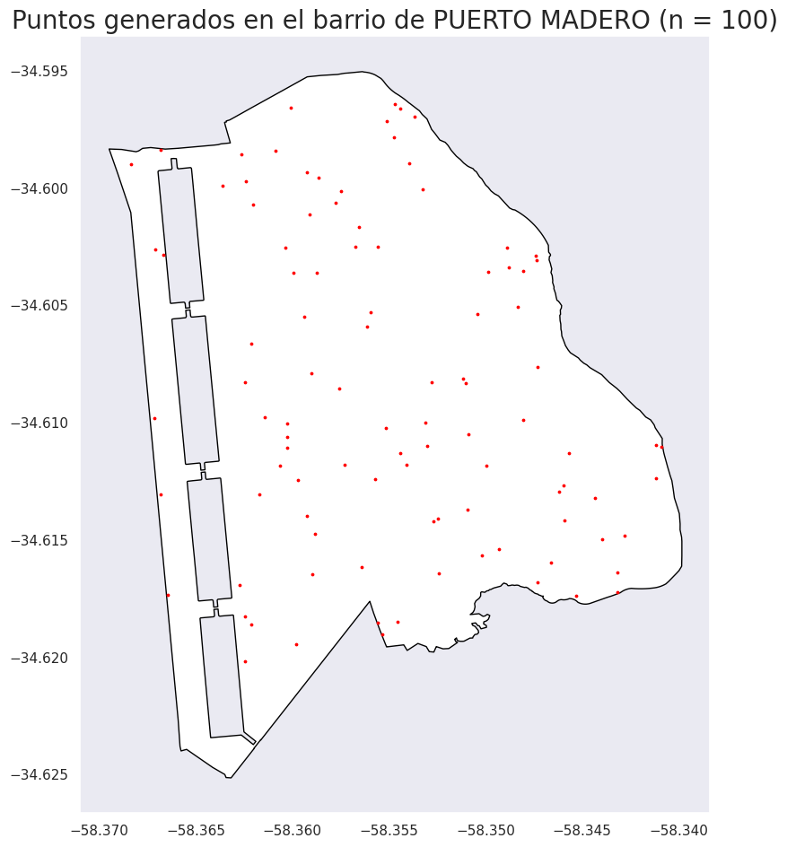

```python
ej5test.graficar_en_barrio('PUERTO MADERO')
```

```
(<Figure size 1000x1000 with 1 Axes>,
 <AxesSubplot: title={'center': 'Puntos generados en el barrio de PUERTO MADERO (n = 100)'}>)
```

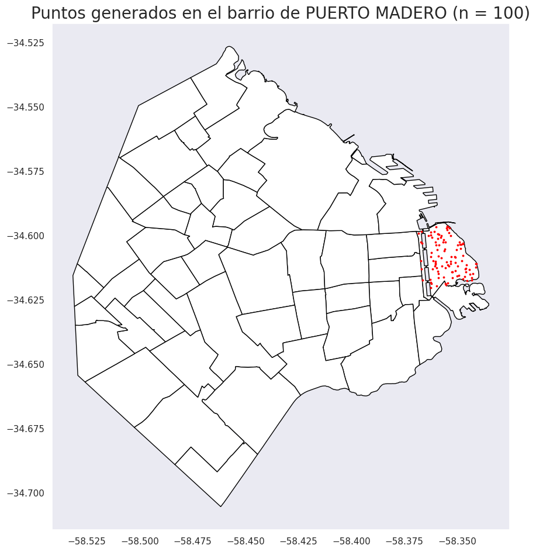

```python
ej5test.graficar_mapa_completo_barrio('PUERTO MADERO')
```

```
(<Figure size 1000x1000 with 1 Axes>,
 <AxesSubplot: title={'center': 'Puntos generados en todos los barrios.'}>)
```

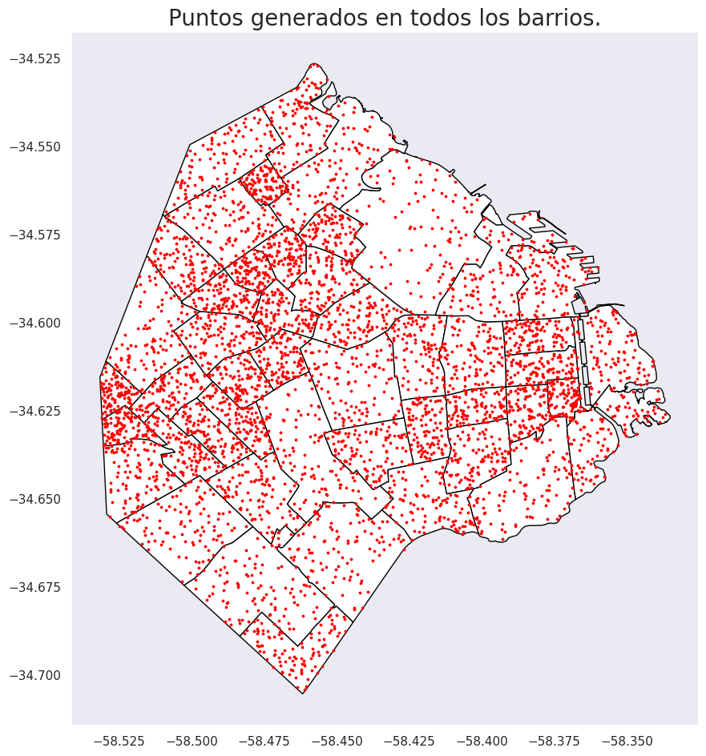

```python
ej5test.graficar_mapa_completo_todos()
```

# Comparaciones con un GCL

```python
# Ahora, rehagamos partes del trabajo, pero basados en un GCL en vez de en LXM
# Son los resultados distintos?
padrones = [97568, 100029, 100033, 104030]
semilla = int(np.mean(padrones))

def GCL(x, a = 1013904223, c = 1664525, m = 232):
    while True:
        x = ((a * x + c) % m) / m
        yield x
```

```python
n = 5
g = GCL(semilla)
print(f"{n} números generados al azar, en el intervalo 0-1:")
for r, i in zip(g,range(n)):
    print(f"* {r}")
```

```
5 números generados al azar, en el intervalo 0-1:
* 0.9224137931034483
* 0.29819411399035617
* 0.5019334719098848
* 0.895838293535956
* 0.008367325211393422
```

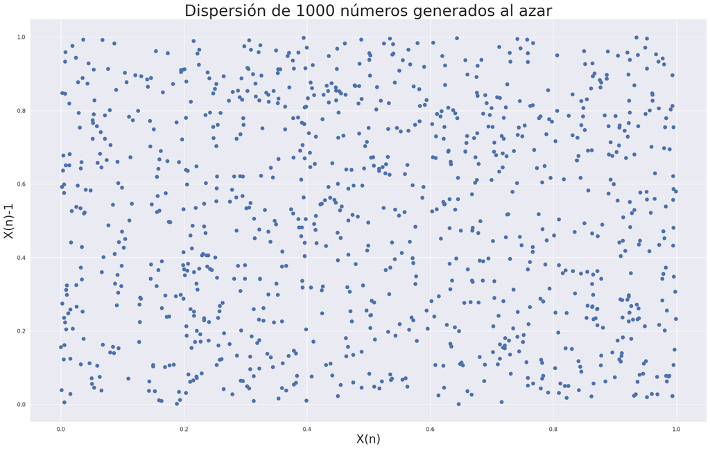

```python
scatterplot.show()
```

```python
Chi2(numero_de_muestras=10000, g=GCL(semilla)).realizar_prueba()
```

```
Frecuencias: [1005, 996, 1013, 1018, 1002, 992, 987, 1020, 994, 973]
Estadístico: 1.94
Límite superior: 11.07
El test acepta la hipotesis nula
```

```
Simulé 7394 arribos en 744.0969199691178 horas
Mi tasa de arribos simulada es de 9.936877578134409 arribos por hora
```

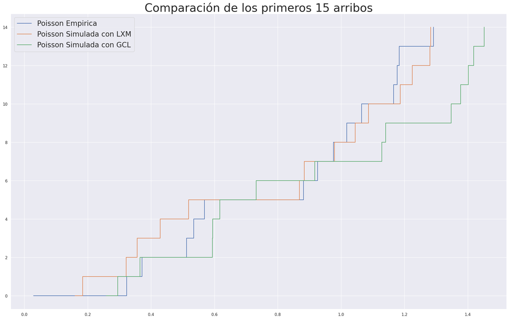

```python
limite = 24 * 31 # Un mes
arribos_gcl = generar_poisson(limite, tasa, GCL(semilla))

print(f"Simulé {len(arribos_gcl)} arribos en {sum(arribos_gcl)} horas")
print(f"Mi tasa de arribos simulada es de {len(arribos_gcl)/sum(arribos_gcl)} arribos por hora")
comparar_poissones([(arribos_real, "Poisson Empirica"), (arribos, "Poisson Simulada con LXM"), (arribos_gcl, "Poisson Simulada con GCL")])
```

```python
ej5test = EJ5(geodataframe, GCL(semilla))
ej5test.generar_en_barrio('PUERTO MADERO', 100)
ej5test.generar_en_todos(100)
```

```
(<Figure size 1000x1000 with 1 Axes>,
 <AxesSubplot: title={'center': 'Puntos generados en el barrio de PUERTO MADERO (n = 100)'}>)
```

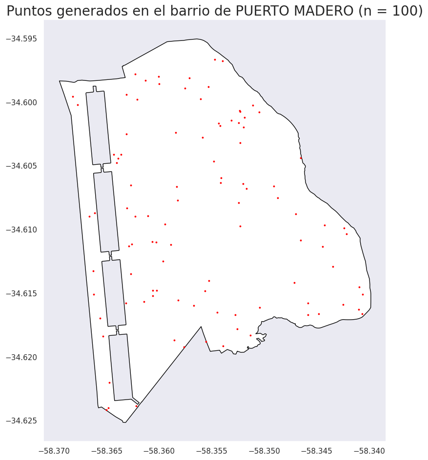

```python
ej5test.graficar_en_barrio('PUERTO MADERO')
```

```
(<Figure size 1000x1000 with 1 Axes>,
 <AxesSubplot: title={'center': 'Puntos generados en el barrio de PUERTO MADERO (n = 100)'}>)
```

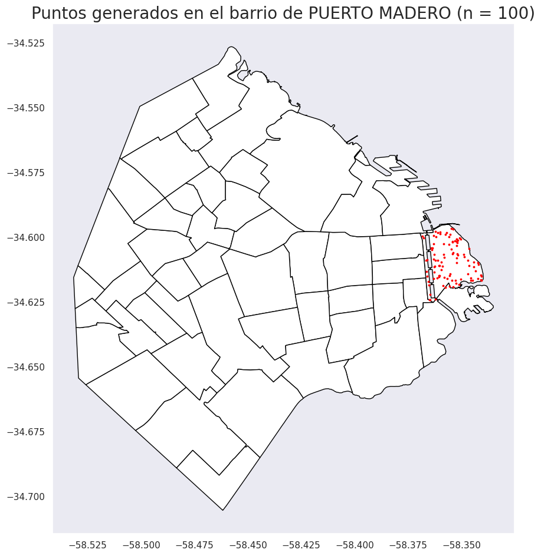

```python
ej5test.graficar_mapa_completo_barrio('PUERTO MADERO')
```

```
(<Figure size 1000x1000 with 1 Axes>,
 <AxesSubplot: title={'center': 'Puntos generados en todos los barrios.'}>)
```

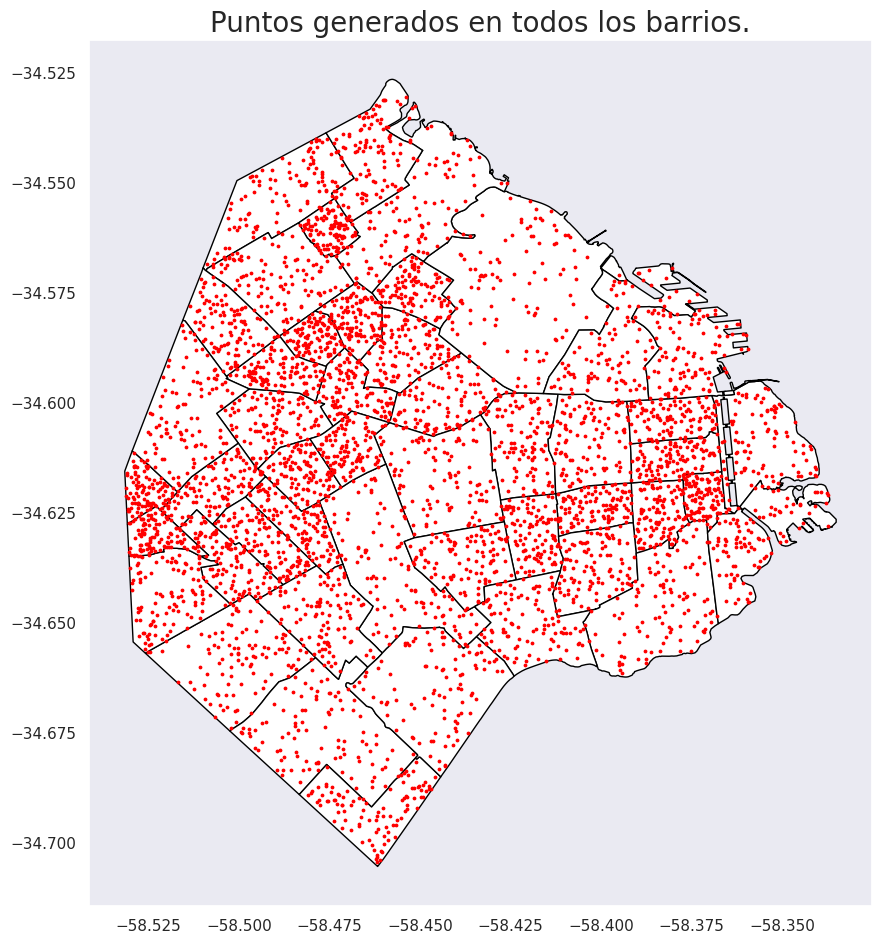

```python
ej5test.graficar_mapa_completo_todos()
```

Conclusión: Los resultados con LXM y con el GCL a lo largo del TP nos parecen bastante similares, lo cual nos parece que tiene muchísimo sentido! LXM se basa fuertemente en un GCL.

# Trabajo Práctico 2

## Page Rank de Actores y Actrices

```python
import os
from bs4 import BeautifulSoup

DIR = 'TP2/paginas'
PAGINAS = os.listdir(DIR)

links = [] # Lista de tuplas de src->dst
palabras = {} # Dict de pagina: palabras

for f in PAGINAS:
    with open(os.path.join(DIR, f)) as file:
        soup = BeautifulSoup(file.read())
        palabras[f] = soup.get_text().split()

        for link in soup.find_all('a'):
            dst = link.get('href').replace('http://','')
            links.append((f,dst))

links
```

```
[('jonvoight.html', 'angelinajolie.html'),
 ('jonvoight.html', 'angelinajolie.html'),
 ('jonvoight.html', 'bradpitt.html'),
 ('bradpitt.html', 'jenniferaniston.html'),
 ('bradpitt.html', 'angelinajolie.html'),
 ('bradpitt.html', 'martinscorcese.html'),
 ('bradpitt.html', 'angelinajolie.html'),
 ('robertdeniro.html', 'martinscorcese.html'),
 ('angelinajolie.html', 'jonvoight.html'),
 ('angelinajolie.html', 'bradpitt.html')]
```

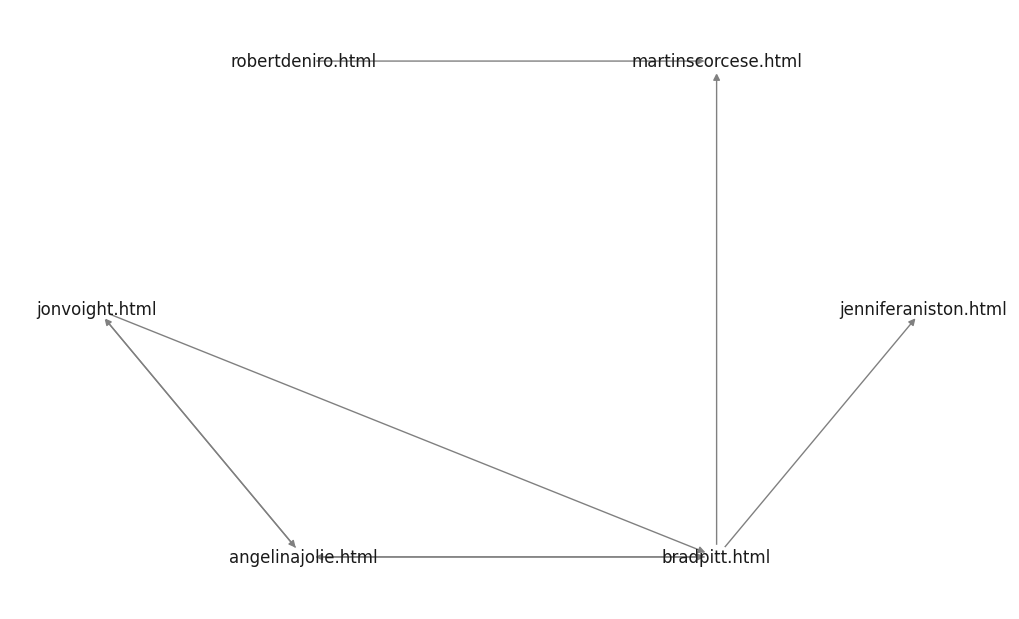

```python
import networkx as nx

G = nx.DiGraph()
G.add_edges_from(links)
nx.draw_shell(G, with_labels=True, node_color='white', edge_color='grey')
```

```python
matriz_ady = nx.to_pandas_adjacency(G)
matriz_ady
```

|  | jonvoight.html | angelinajolie.html | bradpitt.html | jenniferaniston.html | martinscorcese.html | robertdeniro.html |
| --- | --- | --- | --- | --- | --- | --- |
| jonvoight.html | 0.0 | 1.0 | 1.0 | 0.0 | 0.0 | 0.0 |
| angelinajolie.html | 1.0 | 0.0 | 1.0 | 0.0 | 0.0 | 0.0 |
| bradpitt.html | 0.0 | 1.0 | 0.0 | 1.0 | 1.0 | 0.0 |
| jenniferaniston.html | 0.0 | 0.0 | 0.0 | 0.0 | 0.0 | 0.0 |
| martinscorcese.html | 0.0 | 0.0 | 0.0 | 0.0 | 0.0 | 0.0 |
| robertdeniro.html | 0.0 | 0.0 | 0.0 | 0.0 | 1.0 | 0.0 |

```python
suma_filas = matriz_ady.sum(axis=1)
matriz_page_rank = matriz_ady.div(suma_filas, axis=0)
matriz_page_rank.fillna(1/len(PAGINAS), inplace=True)
matriz_page_rank
```

|  | jonvoight.html | angelinajolie.html | bradpitt.html | jenniferaniston.html | martinscorcese.html | robertdeniro.html |
| --- | --- | --- | --- | --- | --- | --- |
| jonvoight.html | 0.000000 | 0.500000 | 0.500000 | 0.000000 | 0.000000 | 0.000000 |
| angelinajolie.html | 0.500000 | 0.000000 | 0.500000 | 0.000000 | 0.000000 | 0.000000 |
| bradpitt.html | 0.000000 | 0.333333 | 0.000000 | 0.333333 | 0.333333 | 0.000000 |
| jenniferaniston.html | 0.166667 | 0.166667 | 0.166667 | 0.166667 | 0.166667 | 0.166667 |
| martinscorcese.html | 0.166667 | 0.166667 | 0.166667 | 0.166667 | 0.166667 | 0.166667 |
| robertdeniro.html | 0.000000 | 0.000000 | 0.000000 | 0.000000 | 1.000000 | 0.000000 |

```python
import numpy as np

# Hacemos N iteraciones de la matriz
iteraciones = np.linalg.matrix_power(matriz_page_rank, 50)

page_rank = {p: iteraciones[0][i] for i, p in enumerate(matriz_page_rank.index)}
page_rank
```

```
{'jonvoight.html': 0.16216216216216203,
 'angelinajolie.html': 0.21621621621621548,
 'bradpitt.html': 0.2432432432432427,
 'jenniferaniston.html': 0.13513513513513484,
 'martinscorcese.html': 0.18918918918918876,
 'robertdeniro.html': 0.05405405405405395}
```

```python
import random

BUSQUEDAS = 20

todas_palabras = set()
for p in palabras.values():
    todas_palabras.update(p)

for p in random.choices(list(todas_palabras), k=BUSQUEDAS):
    matches = [f for f in PAGINAS if p in palabras[f]]
    print(f"'{p}' aparece en: {sorted(matches, key=lambda x: -page_rank[x])}")
```

```
'&' aparece en: ['bradpitt.html', 'angelinajolie.html']
'romantic' aparece en: ['jenniferaniston.html']
'him' aparece en: ['bradpitt.html']
'collaborated' aparece en: ['martinscorcese.html']
'Jolie's' aparece en: ['angelinajolie.html']
'two' aparece en: ['bradpitt.html', 'angelinajolie.html']
'Interrupted' aparece en: ['angelinajolie.html']
'4,' aparece en: ['angelinajolie.html']
'one.' aparece en: ['bradpitt.html']
'America.' aparece en: ['martinscorcese.html']
'Raider' aparece en: ['angelinajolie.html']
'Thelma' aparece en: ['bradpitt.html']
'Troy' aparece en: ['bradpitt.html']
'actress.' aparece en: ['jenniferaniston.html']
'17,' aparece en: ['martinscorcese.html', 'robertdeniro.html']
'(1993).' aparece en: ['angelinajolie.html']
'School' aparece en: ['martinscorcese.html']
'six' aparece en: ['jonvoight.html']
'Knox,' aparece en: ['bradpitt.html', 'angelinajolie.html']
'&' aparece en: ['bradpitt.html', 'angelinajolie.html']
```

# Diseño del Web Service

```python
from scipy.stats import expon, uniform
```

```python
class Consulta:
    def __init__(self, tiempo_arribo, duracion, tiempo_finalizacion_anterior):
        if tiempo_arribo < tiempo_finalizacion_anterior:
            self.duracion_espera = tiempo_finalizacion_anterior - tiempo_arribo
            self.tuvo_que_esperar = True
        else:
            self.duracion_espera = 0
            self.tuvo_que_esperar = False

        self.tiempo_finalizacion = tiempo_arribo + duracion + self.duracion_espera
```

```python
def simular_consultas(tiempos_de_arribo, duraciones):
    consultas = []

    # Uso -1 como tiempo de finalizacion del anterior para que empieze ni bien llega
    primera_consulta = Consulta(tiempos_de_arribo[0], duraciones[0], tiempo_finalizacion_anterior = -1)
    consultas.append(primera_consulta)

    for tiempo_arribo, duracion in zip(tiempos_de_arribo[1:], duraciones[1:]):
        consulta = Consulta(tiempo_arribo,
                        duracion,
                        tiempo_finalizacion_anterior = consultas[-1].tiempo_finalizacion)
        consultas.append(consulta)

    tiempo_espera_total = 0
    cant_consultas_que_no_esperaron = 0
    for consulta in consultas:
        tiempo_espera_total += consulta.duracion_espera
        if not consulta.tuvo_que_esperar:
            cant_consultas_que_no_esperaron += 1

    return tiempo_espera_total, cant_consultas_que_no_esperaron
```

```python
def mostrar_resultados(titulo, tiempo_espera_total, cant_consultas_que_no_esperaron, cant_consultas):
    print(f"--------------{titulo}--------------")
    print(f"\tEl tiempo de espera promedio fue {(round(tiempo_espera_total / cant_consultas, 2))} segundos")
    print(f"\tEl {cant_consultas_que_no_esperaron/cant_consultas}% de las consultas no tuvo que esperar")
```

```python
def simular_consultas_centralizado(cant_consultas, media_tiempos_de_arribo, media_duraciones_consultas):
    tiempos_de_arribo = expon.rvs(size=cant_consultas, scale=media_tiempos_de_arribo)
    duraciones = expon.rvs(size=cant_consultas, scale=media_duraciones_consultas)
    return simular_consultas(tiempos_de_arribo, duraciones)
```

```python
t, f = simular_consultas_centralizado(100000, 4, 0.8)
mostrar_resultados("Base de datos central", t,f, 100)
```

```
--------------Base de datos central--------------
	El tiempo de espera promedio fue 40080682.47 segundos
	El 0.03% de las consultas no tuvo que esperar
```

```python
def simular_consultas_distribuido(cant_consultas, media_tiempos_de_arribo,
                                  media_duraciones_consultas1, media_duraciones_consultas2, p):
    tiempos_de_arribo = expon.rvs(size=cant_consultas, scale=media_tiempos_de_arribo)
    u = uniform.rvs(size=cant_consultas)

    tiempos_de_arribo1 = []
    tiempos_de_arribo2 = []

    for ui, tiempo_de_arribo in zip(u, tiempos_de_arribo):
        if p <= ui:
            tiempos_de_arribo1.append(tiempo_de_arribo)
        else:
            tiempos_de_arribo2.append(tiempo_de_arribo)


    duraciones1 = expon.rvs(size=len(tiempos_de_arribo1), scale=media_duraciones_consultas1)
    t1, f1 = simular_consultas(tiempos_de_arribo1, duraciones1)

    duraciones2 = expon.rvs(size=len(tiempos_de_arribo2), scale=media_duraciones_consultas2)
    t2, f2 = simular_consultas(tiempos_de_arribo2, duraciones2)

    return t1, f1, len(tiempos_de_arribo1), t2, f2, len(tiempos_de_arribo2)
```

```python
t1, f1, l1, t2, f2, l2 = simular_consultas_distribuido(100000, 4, 0.7, 1, 0.7)
mostrar_resultados("Ambas bases distribuidas", t1 + t2, f2 + f2, l1 + l2)
mostrar_resultados("Base de datos distribuida 1", t1, f1, l1)
mostrar_resultados("Base de datos distribuida 2", t2, f2, l2)
```

```
--------------Ambas bases distribuidas--------------
	El tiempo de espera promedio fue 27660.41 segundos
	El 4e-05% de las consultas no tuvo que esperar
--------------Base de datos distribuida 1--------------
	El tiempo de espera promedio fue 10571.37 segundos
	El 0.00010006337346986425% de las consultas no tuvo que esperar
--------------Base de datos distribuida 2--------------
	El tiempo de espera promedio fue 34977.66 segundos
	El 2.8563675573772835e-05% de las consultas no tuvo que esperar
```